# Reproducible Research: Peer Assessment 1

Victoria Cocco

# This assignment makes use of data from a personal activity monitoring device. This device collects data

# at 5 minute intervals through out the day. The data consists of two months of data from an anonymous

# individual collected during the months of October and November, 2012 and include the number of steps

# taken in 5 minute intervals each day.

# This report shows the results from a number of inquiries regarding the data and can be used across a dataset incorporating other date ranges.

## Loading and preprocessing the data

### Load the data (i.e. read.csv())

### Process/transform the data (if necessary) into a format suitable for your analysis

```r
        install.packages('dplyr', repos="http://cran.rstudio.com/")
        library(dplyr)
        install.packages('dtplyr', repos="http://cran.rstudio.com/")
        library(dtplyr)
```

```r
        install.packages('ggplot2', repos="http://cran.rstudio.com/")
        library(ggplot2)
        workingdir <- getwd()

        destfile <- paste(workingdir, "/activity.csv", sep = "")
        if (!file.exists(destfile)) {
                print("got here")
                #  messge stub for a possible error handler
                print(paste("activity.csv ",
                            "does not exist in the working direct ",
                            "- please put it there"))

        } else {

                activity <- read.csv("activity.csv" , header = TRUE)
                tblactivity <- tbl_df(activity)
                rm(activity)
        }
```

## What is mean total number of steps taken per day?

### Make a histogram of the total number of steps taken each day

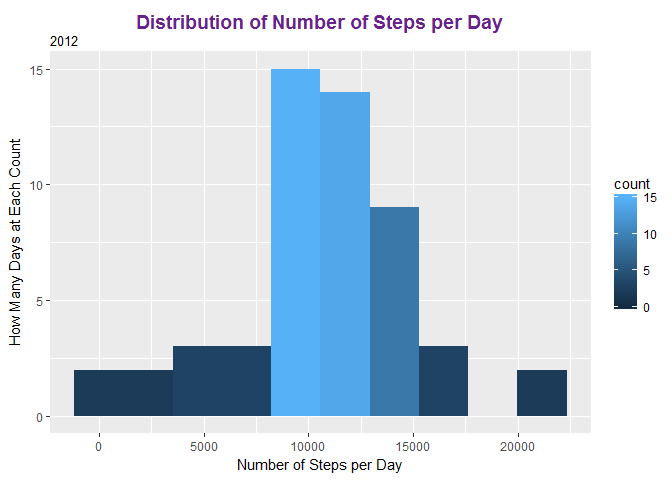

```r
        tblsteps <- tblactivity %>%
        select(steps,
               date,
               interval) %>%
        filter(!is.na(steps))%>%
        mutate(intervaldate = as.Date(date, format = "%Y-%m-%d")) %>%
        arrange(intervaldate) %>%
        group_by(intervaldate) %>%
        summarise(daysteps = sum(steps))

        plot1 <- ggplot(tblsteps, aes(daysteps))
        plot1 <- plot1 + geom_histogram(bins = 10, aes(fill = ..count..))
        plot1 <- plot1 + labs(x = "Number of Steps per Day" ,
                              y = "How Many Days at Each Count",
                              title = "Distribution of Number of Steps per Day",
                              subtitle = "2012")
        plot1 <- plot1 + theme(plot.title=element_text(size=14,
                                                       hjust=0.5,
                                                       face="bold",
                                                       colour="darkorchid4",
                                                       vjust=-1))


        print(plot1)
```

### Calculate and report the mean and median total number of steps taken per day

```r
        tblstats <- tblactivity %>%
                select(steps,
                       date) %>%
                filter(!is.na(steps)) %>%
                group_by(date) %>%
                summarise(totalsteps = sum(steps))

        tblstats <- tblstats %>%
                select(totalsteps) %>%
                summarise(meansteps = mean(totalsteps), mediansteps = median(totalsteps))

        strmean <- paste("The mean total number of steps take per day = ",
                         format(tblstats$meansteps, nsmall = 3))
        strmedian <- paste("The median total number of steps take per day = ",
                         tblstats$mediansteps)
        print(strmean)
```

```
## [1] "The mean total number of steps take per day =  10766.189"
```

```r
        print(strmedian)
```

```
## [1] "The median total number of steps take per day =  10765"
```

## What is the average daily activity pattern?

### Make a time series plot of the 5-minute interval x-axis,

### and the average number of steps taken, averaged across all days y-axis

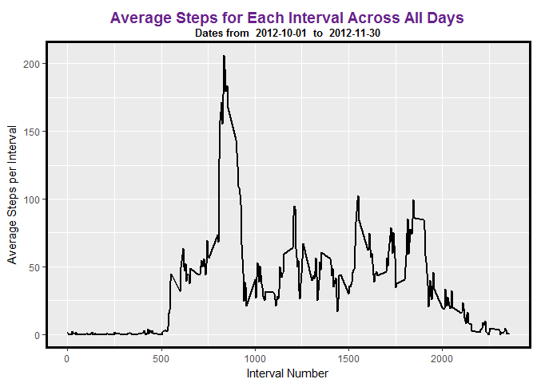

```r
        tblintervals <- tblactivity %>%
                select(steps,
                       interval,
                       date) %>%
                filter(!is.na(steps)) %>%
                arrange(interval) %>%
                group_by(interval) %>%
                summarise(intervalmeansteps = mean(steps))

        # get the interval with the highest mean of steps
        tblmaxinterval <- tblintervals %>%
                        arrange(intervalmeansteps)

        # find the max mean step interval
        maxrow <- nrow(tblmaxinterval)
        maxinterval <- tblmaxinterval[maxrow, 1]
        maxmeansteps <- tblmaxinterval[maxrow,2]

        # get the interval dates
        tbldates <- tblactivity %>%
                select(date) %>%
                mutate(intervaldate = as.Date(date, format = "%Y-%m-%d")) %>%
                arrange(intervaldate) %>%
                summarise(mindate = min(intervaldate), maxdate = max(intervaldate))


        mindate <- tbldates[1,1]
        maxdate <- tbldates[1,2]

        # plot the histogram of steps each day
        plot3 <- ggplot(tblintervals, aes(x =interval,
                                      y = intervalmeansteps))
        plot3 <- plot3 + geom_line(size=1)
        plot3 <- plot3 + labs(x = "Interval Number" ,
                              y = "Average Steps per Interval",
                              title = "Average Steps for Each Interval Across All Days",
                              subtitle = paste("Dates from ",
                                                format(mindate, format="%Y-%m-%d"),
                                                " to ",
                                                format(maxdate, format="%Y-%m-%d")))
        plot3 <- plot3 + theme(plot.title=element_text(size=14,
                                                       hjust=0.5,
                                                       face="bold",
                                                       colour="darkorchid4",
                                                       vjust=-1))
        plot3 <- plot3 + theme(plot.subtitle=element_text(size=10,
                                                          hjust=0.5,
                                                          face="bold",
                                                          colour="black",
                                                          vjust=-1))
        plot3 <- plot3 + theme(panel.border = element_rect(colour = "black",
                                                           fill=NA,
                                                           size=2))


        print(plot3)
```

```r
        submsg <- "Highest average interval "
        submsg <- paste(submsg, maxinterval)
        submsg <- paste(submsg, " with a mean of ")
        submsg <- paste(submsg, format(maxmeansteps, nsmall=3))
        print(submsg)
```

```
## [1] "Highest average interval  835  with a mean of  206.1698"
```

## Imputing missing values

### Calculate and report the total number of missing values in the dataset

### (i.e. the total number of rows with NAs)

```r
        tblNAs <- tblactivity %>%
        select(steps,
               interval,
               date) %>%
        filter(is.na(steps))

        numNAs <- nrow(tblNAs)
        strmsg <- "The total number of missing values in the dataset is "
        print(paste(strmsg, numNAs))
```

```
## [1] "The total number of missing values in the dataset is  2304"
```

### Devise a strategy for filling in all of the missing values in the dataset.

### The strategy does not need to be sophisticated.

### For example, you could use the mean/median for that day,

### or the mean for that 5-minute interval, etc.

### Create a new dataset that is equal to the original dataset but with the missing data filled in

```r
        tblstats <- tblactivity %>%
                select(steps,
                       date) %>%
                filter(!is.na(steps)) %>%
                group_by(date) %>%
                summarise(totalsteps = sum(steps))

        tblstats <- tblstats %>%
                select(totalsteps) %>%
                summarise(meansteps = mean(totalsteps), mediansteps = median(totalsteps))
                tblstats <- tblactivity %>%
                select(steps,
                       date) %>%
                filter(!is.na(steps)) %>%
                group_by(date) %>%
                summarise(totalsteps = sum(steps))

        tblstats <- tblstats %>%
                select(totalsteps) %>%
                summarise(meansteps = mean(totalsteps), mediansteps = median(totalsteps))


        tblintervalmeans <- tblactivity %>%
                select(steps,
                       interval,
                       date) %>%
                filter(!is.na(steps)) %>%
                arrange(interval) %>%
                group_by(interval) %>%
                summarise(intervalmeansteps = mean(steps))

        tblintervals <- tblactivity %>%
                select(steps,
                       interval,
                       date) %>%
                filter(!is.na(steps))

        tblimputedNAs <- left_join(tblNAs, tblintervalmeans, by = "interval")
        tblimputedNAs <- select(tblimputedNAs, intervalmeansteps, interval, date)
        colnames(tblimputedNAs) <- c('steps', 'interval', 'date')

        tblcomplete <- rbind(tblintervals, tblimputedNAs)

        tblsteps <- tblcomplete %>%
                select(steps,
                       date,
                       interval) %>%
                filter(!is.na(steps))%>%
                mutate(intervaldate = as.Date(date, format = "%Y-%m-%d")) %>%
                arrange(intervaldate) %>%
                group_by(intervaldate) %>%
                summarise(daysteps = sum(steps))
```

### Make a histogram of the total number of steps taken each day and

### Calculate and report the mean and median total number of steps taken per day.

### Do these values differ from the estimates from the first part of the assignment?

### What is the impact of imputing missing data on the estimates of the total daily number of steps?

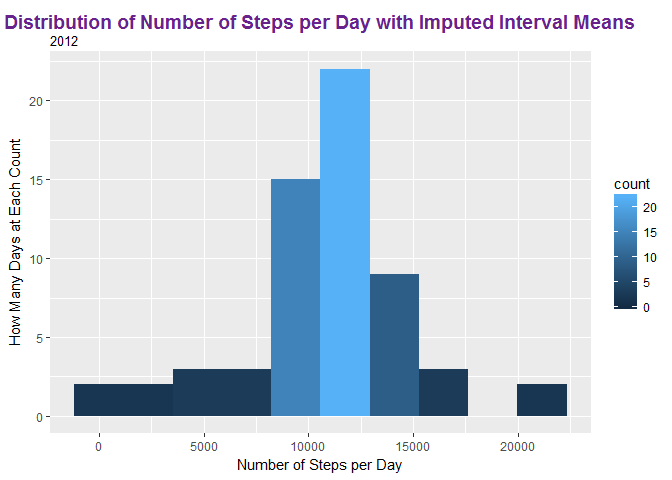

```r
        tblsteps <- tblcomplete %>%
                select(steps,
                       date,
                       interval) %>%
                filter(!is.na(steps))%>%
                mutate(intervaldate = as.Date(date, format = "%Y-%m-%d")) %>%
                arrange(intervaldate) %>%
                group_by(intervaldate) %>%
                summarise(daysteps = sum(steps))

        tblsteps <- tblcomplete %>%
                select(steps,
                        date,
                        interval) %>%
                filter(!is.na(steps))%>%
                mutate(intervaldate = as.Date(date, format = "%Y-%m-%d")) %>%
                arrange(intervaldate) %>%
                group_by(intervaldate) %>%
                summarise(daysteps = sum(steps))
        plot4 <- ggplot(tblsteps, aes(daysteps))
        plot4 <- plot4 + geom_histogram(bins = 10, aes(fill = ..count..))
        plot4 <- plot4 + labs(x = "Number of Steps per Day" ,
                      y = "How Many Days at Each Count",
                      title = "Distribution of Number of Steps per Day with Imputed Interval Means",
                      subtitle = "2012")
        plot4 <- plot4 + theme(plot.title=element_text(size=14,
                                                       hjust=0.5,
                                                       face="bold",
                                                       colour="darkorchid4",
                                                       vjust=-1))

        print(plot4)
```

```r
        tblimputedstats <- tblcomplete %>%
                select(steps,
                       date) %>%
                filter(!is.na(steps)) %>%
                group_by(date) %>%
                summarise(totalsteps = sum(steps))

        tblimputedstats <- tblimputedstats %>%
                select(totalsteps) %>%
                summarise(meansteps = mean(totalsteps), mediansteps = median(totalsteps))

        imputedmeandiff <- format(tblstats$meansteps - tblimputedstats$meansteps, nsmall=3)
        imputedmediandiff <- tblstats$mediansteps - tblimputedstats$mediansteps

        strmsg <- "The difference between mean with NAs and the imputed mean is "
        strmsg <- paste(strmsg, imputedmeandiff)
        print(strmsg)
```

```
## [1] "The difference between mean with NAs and the imputed mean is  0.000"
```

```r
        strmsg <- "The difference between median with NAs and the imputed median is "
        strmsg <- paste(strmsg, imputedmediandiff)
        print(strmsg)
```

```
## [1] "The difference between median with NAs and the imputed median is  -1.1886792452824"
```

## Are there differences in activity patterns between weekdays and weekends?

### Create a new factor variable in the dataset with two levels – “weekday” and “weekend”

### indicating whether a given date is a weekday or weekend day.

```r
        tbldaysteps <- tblcomplete %>%
                select(steps,
                       interval,
                       date) %>%
                mutate(intervaldate = as.Date(date, format = "%Y-%m-%d"))

        tbldaysteps <- tbldaysteps %>%
                select(steps,
                       interval,
                       intervaldate) %>%
                mutate(datetype =  ifelse(weekdays(intervaldate)=="Saturday" |                                       weekdays(intervaldate)=="Sunday", "Weekend", "Weekday")) %>%
                arrange(datetype, interval) %>%
                group_by(datetype, interval) %>%
                summarise(meansteps = mean(steps))
```

### Make a panel plot containing a time series plotof the 5-minute interval (x-axis)

### and the average number of steps taken,

### averaged across all weekday days or weekend days (y-axis).

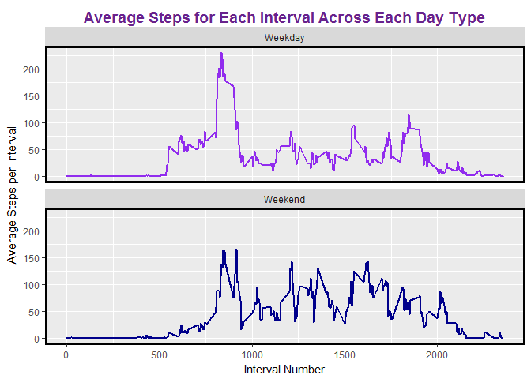

```r
              cbPalette <- c("purple2",
                               "blue4")

                #create the plot
                plot5 <- ggplot(tbldaysteps, aes(x= interval,
                                             y= meansteps,
                                             group = datetype,
                                             colour= datetype))
                plot5 <- plot5 + geom_line(size = 1)
                plot5 <- plot5 + scale_colour_manual(values = cbPalette)
                plot5 <- plot5 + facet_wrap(~ datetype, ncol = 1, nrow = 2)
                plot5 <- plot5 + labs(x = "Interval Number" ,
                                      y = "Average Steps per Interval",
                                      title = "Average Steps for Each Interval Across Each Day Type")
                plot5 <- plot5 + theme(plot.title=element_text(size=14,,
                                                                hjust=0.5,
                                                                face="bold",
                                                                colour="darkorchid4",
                                                                vjust=-1))
               plot5 <- plot5 + theme(panel.border = element_rect(colour = "black",
                                                                   fill=NA,
                                                                   size=2))
                plot5 <- plot5 + theme(legend.position="none")
                print(plot5)
```